# **CSI500 Fold 0 2018 起点实验报告**

模型结构 数据输入 损失函数与收敛诊断

# **一 实验结论**

本报告记录 CSI500 Fold 0 的 2018 起点修正版实验。原始日期窗为 2018-01-02 至 2020-12-31 训练、2021 年验证和 2022-01-04 至 2022-12-30 样本外。按 20 日标签的实际退出日期清除边界交叠后，训练期实际截至 2020-12-03，验证期实际截至 2021-12-03。训练最大轮数为 100，早停 patience 为 20，实际记录 epoch 0 至 39。

当前 long_only_softmax 配置没有执行单股仓位上限。样本外单股权重极值为 100.00%，真正的有效持仓约为 4.98 至 7.73 只，阈值筛选的平均入选股票数约为 36.4 至 61.1 只。这些结果用于诊断修正版数据链路与现有模型配置，不能代表满足 0.5% 业务约束的策略结果。

- 模型的早停依据为 validation_loss，即四项损失加权后的验证集总损失。
- 输入因子来自新的 64 因子 H5 面板，行业信息来自 H5 对齐后的一级行业面板。
- 五个期限的主标签严格使用论文公式 VWAP[t+h] / VWAP[t+1] - 1；t+h+1 版本作为 legacy 敏感性定义保留。
- 因子等权基准为有效单因子横截面 softmax 组合的等权平均，不使用学习得到的因子注意力。

# **二 实验区间与运行设置**

| **项目** | **设置** |
| --- | --- |
| 股票池 | CSI500 历史成员；按交易日精确匹配，不使用未来成员回填 |
| 训练期 | 原始 2018-01-02 至 2020-12-31；清除后截至 2020-12-03 |
| 验证期 | 原始 2021-01-04 至 2021-12-31；清除后截至 2021-12-03 |
| 样本外期 | 2022-01-04 至 2022-12-30 |
| 预测期限 | 3、5、10、15、20 个交易日 |
| 最大 epoch | 100 |
| 实际停止 | 记录 epoch 0 至 39，共 40 轮 |
| 最佳验证轮 | epoch 19；validation_loss=-0.163972 |
| 早停 patience | 20 |
| 设备 | CUDA GPU |
| 批次 | 每批 8 个交易日 |
| 随机种子 | 42 |

# **三 输入数据细节**

| **数据项** | **来源与处理** |
| --- | --- |
| 因子面板 | /cloud/factor_synthesis/data/alphagat_64f_fixed_2018_2026_t1t2_vwap |
| 因子数量 | 64 个新 H5 选出因子；不是原始高频因子集合 |
| 市场与成员数据 | /cloud/hdf5/historical/china_astock_2018.h5 对齐生成 CSI500 历史成员 |
| 行业数据 | /cloud/E2EAI/data/index_universes/industry_level1_h5_2018_2026.npz |
| 行业层级 | Citic 一级行业；与交易日和股票轴对齐 |
| 因子输入形状 | [B, N, 64]，B 为交易日批次，N 为当日有效股票数 |
| 成员筛选 | 历史成员精确日期匹配；不做未来日期回填 |
| 股票数截断 | 当前 index 配置不做市场规模截断；max_assets_per_date=null |
| 切分样本数 | 训练 710、验证 223、样本外 242 个交易日 |
| 收益标签 | 论文公式版：VWAP[t+h] / VWAP[t+1] - 1 |
| 基准收益 | 决策日指数权重调整 VWAP 收益代理；缺失标签重新归一化 |

本次修正版采用论文公式版，因此 h=3、5、10、15、20 对应的退出位置分别是 t+3、t+5、t+10、t+15、t+20；原 t+h+1 版本保留为 legacy 敏感性测试。训练集和验证集均按最大退出偏移清除跨边界标签，样本外评价仍采用 overlapping label 模式，年化使用 252/h。

# **四 模型网络结构**

模型输入为每个交易日的 64 因子横截面和两张关系图。主路径依次经过动态因子选择、股票上下文编码、行业 GAT 中性化、股票池 GAT 中性化、五个独立深度因子头和五个独立组合分配头。

| **模块** | **输入** | **网络层** | **输出与关键设置** |
| --- | --- | --- | --- |
| 动态因子选择 | [B,N,64] | 横截面均值 → Linear 64→32 → LeakyReLU(0.2) → Linear 32→64 → Softmax | [B,N,64]；gamma_f=0.02；训练 STE hard，测试 hard |
| 上下文编码 | 选中因子 [B,N,64] | 逐日期逐因子横截面标准化 → Linear 64→64 → LeakyReLU(0.2) → Dropout 0.10 → Linear 64→64 | stock_context [B,N,64] |
| 行业中性化 | 上下文与行业图 | 单头 GAT 64→64；注意力 dropout 0.10；self-loop；ELU；残差相减 | industry_neutral [B,N,64] |
| 股票池中性化 | 行业中性结果与股票池图 | 结构同上，输入为 industry_neutral，不重新使用原始上下文 | universe_neutral [B,N,64] |
| 深度因子头 | 3 个 64 维表示拼接 | 5 个独立 Linear 192→1 → LeakyReLU(0.2) | deep_factors [B,5,N]；不共享期限头 |
| 因子解释头 | 选中因子 [B,N,64] | 5 个独立 Linear 64→64 → LeakyReLU(0.2) → 因子维 softmax | factor attention 与 deep factor approximation |
| 组合分配头 | 上下文 64 维 + signed deep factor 1 维 | 5 个独立 Linear 65→1 → LeakyReLU(0.2) → 股票维 masked softmax | portfolio_weights [B,5,N] |

当前组合分配模式为 long_only_softmax：权重非负、每个日期和期限的权重和为 1，gamma_p=0.001，至少保留 1 只股票。theta=0.10 仅是旧 capped-simplex 模式的兼容字段，本次 no-cap 运行不生效。

需要审查的集中度事实：当前运行没有启用 0.5% 单股权重上限，模型样本外单股权重极值为 100.00%；有效持仓和阈值入选数分别列示，不能混用。

# **五 损失函数**

当前 long_only_softmax 路径的总损失为：

**L_total = L_portfolio + 0.10 L_stability + 0.10 L_factor + 0.10 L_approximation**

| **损失项** | **定义与作用** | **权重** |
| --- | --- | --- |
| L_portfolio | 组合收益损失，等于 -mean(portfolio return)。缺失收益标签按有效权重重新归一化。 | 1.00 |
| L_stability | 方向加权 ICIR 的负值；通过横截面 IC 和时间序列 ICIR 约束深度因子方向稳定性。 | 0.10 |
| L_factor | 局部横截面回归得到的 psi 与历史 deep direction 的方向收益损失，目标是最大化方向一致的因子收益。 | 0.10 |
| L_approximation | deep_factors 与因子注意力方向近似 deep_factor_approx 的 masked MSE。 | 0.10 |
| 上限损失 | long_only_softmax 路径不加入 upper_bound_loss；不会在本次训练中惩罚单股权重超过 theta。 | 不启用 |

验证集早停监控的是上述 L_total 的 validation_loss，而不是单独的收益损失、ICIR 或因子近似损失。当前实验使用 AdamW，学习率 0.001，weight decay 0.0001，无学习率调度，梯度裁剪范数 5.0。

# **六 样本外结果**

下表中的换手率是每个期限单独计算的目标权重换手，不是带漂移、交易成本和实际成交路径的执行换手。

## **六点一 模型组合**

| **期限 h** | **年化收益** | **年化超额** | **最大回撤** | **单次换手** | **有效持仓** | **平均入选** |
| --- | --- | --- | --- | --- | --- | --- |
| 3 | -5.17% | 6.04% | 16.50% | 19.96% | 7.73 | 61.1 |
| 5 | -12.56% | -0.34% | 19.13% | 19.47% | 5.16 | 42.1 |
| 10 | -1.38% | 11.19% | 21.45% | 24.46% | 6.05 | 44.3 |
| 15 | 1.42% | 12.88% | 18.69% | 23.95% | 6.06 | 46.0 |
| 20 | 14.17% | 23.44% | 16.66% | 25.31% | 4.98 | 36.4 |

## **六点二 因子等权基准**

| **期限 h** | **年化收益** | **年化超额** | **最大回撤** | **单次换手** | **有效持仓** | **平均入选** |
| --- | --- | --- | --- | --- | --- | --- |
| 3 | -5.03% | 6.18% | 14.20% | 3.39% | 422.05 | 496.3 |
| 5 | -5.49% | 6.73% | 18.50% | 3.39% | 422.05 | 496.3 |
| 10 | -6.06% | 6.51% | 16.05% | 3.39% | 422.05 | 496.3 |
| 15 | -4.58% | 6.89% | 17.58% | 3.39% | 422.05 | 496.3 |
| 20 | -2.24% | 7.03% | 11.95% | 3.39% | 422.05 | 496.3 |

因子等权基准的有效持仓约 422 只，平均入选股票约 496 只，最大单股权重约 2.11%，而模型组合由于没有仓位上限而呈现明显集中。该差异是解释模型与基准表现差异时必须保留的配置因素。

# **七 逐日执行回测**

逐日回测将决策日 t 的目标权重在下一交易日 t+1 的复权 VWAP 执行，持仓在相邻交易日之间按价格漂移，再依据新目标权重调仓。下表使用实际每日净值；本次交易成本为 0 bps，换手率为漂移后权重到目标权重的单边换手。

| **h** | **组合** | **年化收益** | **年化超额** | **最大回撤** | **主动回撤** | **日均单边换手** |
| --- | --- | --- | --- | --- | --- | --- |
| 3 | 模型 | -18.79% | 0.20% | 28.39% | 13.24% | 19.89% |
| 3 | 因子等权 | -10.61% | 10.29% | 25.83% | 1.17% | 3.54% |
| 5 | 模型 | -24.38% | -6.70% | 32.76% | 26.88% | 19.37% |
| 5 | 因子等权 | -10.61% | 10.29% | 25.83% | 1.17% | 3.54% |
| 10 | 模型 | -20.11% | -1.43% | 30.00% | 14.60% | 24.38% |
| 10 | 因子等权 | -10.61% | 10.29% | 25.83% | 1.17% | 3.54% |
| 15 | 模型 | -21.44% | -3.07% | 30.81% | 15.61% | 23.87% |
| 15 | 因子等权 | -10.61% | 10.29% | 25.83% | 1.17% | 3.54% |
| 20 | 模型 | -17.44% | 1.86% | 29.91% | 14.08% | 25.21% |
| 20 | 因子等权 | -10.61% | 10.29% | 25.83% | 1.17% | 3.54% |

# **八 损失函数收敛曲线**

下图为本次最终运行生成的训练目标曲线。训练在最大 100 轮之前因 validation_loss 连续 20 轮没有改善而早停。曲线显示总损失和验证损失仍存在明显波动，因此本次实验说明模型完成了既定早停流程，但不能将其表述为已经达到全局收敛。

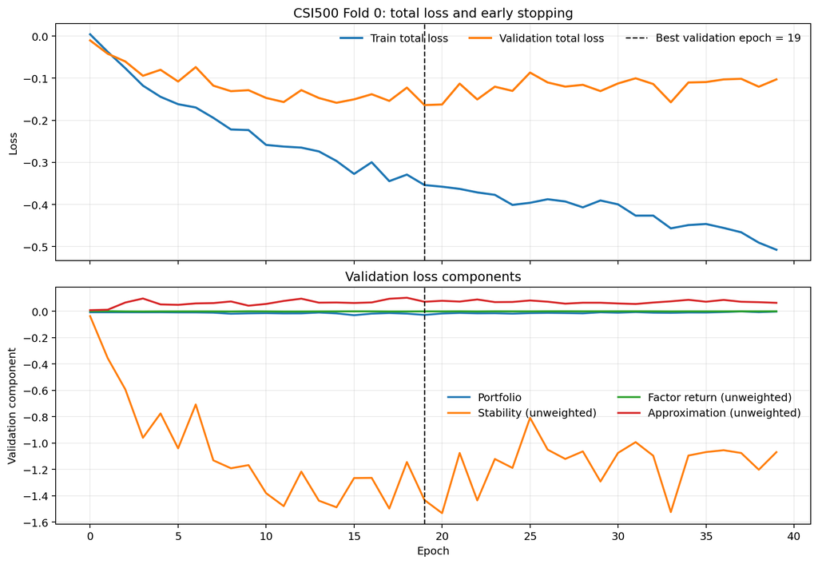

图 1 本次 CSI500 Fold 0 训练目标与验证损失曲线

# **九 审查重点**

- 确认评估是否应严格启用此前提出的 0.5% 单股权重上限；本次结果没有启用该约束。
- 确认 no-cap long-only-softmax 是否属于论文目标配置，还是仅用于网络联通性和数据接口测试。
- 重点检查 validation_loss 在后半程的波动、早停轮数与学习率之间的关系。
- 区分模型表现与组合约束差异：因子等权基准高度分散，而当前模型组合高度集中。
- 如需论文正式结果，应在确定仓位约束、交易成本和非重叠回测口径后重新运行。
- 论文表 1 汇总 2015 年至 2022 年中多组时间切分，本报告仅为 2022 年单折，不能直接做数值复现比较。